# Jakolof Bay Bivalve Filtration

### Mussel clearance rates

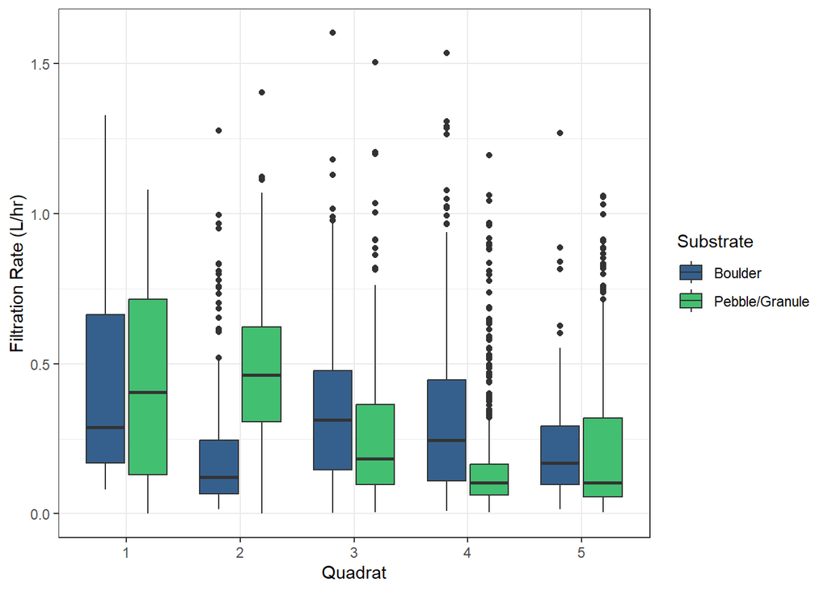

Estimated clearance rates for all mussels within each substrate type from the low edge (quadrat 1) to the high edge (quadrat 5) for all measured sites.

### Spatial analyses

#### Jakolof Bay physical characteristics

[interactive chart not shown]

Substrate polygons in Jakolof Bay.

Total estimated surface area of Jakolof Bay intertidal (m<sup>2</sup>):

```
[1] 663820.4
```

The approximate length of the long axis of the bay was calculated at ~4.5 km and the widest point was ~820 m.

Mean tidal exchange volume for Jakolof Bay (3 m exchange, m<sup>3</sup> hr<sup>-1</sup>)

```
[1] 6710768
```

#### Mussel filtration

Table 1: Estimated number of mussels across all habitat types

```
# A tibble: 5 × 2
  substrate      total_mussels
  <chr>                  <dbl>
1 bedrock             2518275.
2 boulder            11423558.
3 mud_organic          703284.
4 pebble_granule     58356535.
5 unknown            40896031.
```

Total estimated number of mussels in the Jakolof Bay:

```
[1] 113897683
```

Total estimated wet weight of mussels in the bay (kg):

```
[1] 192042
```

Table 2: Total liters filtered per hour per substrate type.

```
# A tibble: 5 × 2
  substrate      total_filtration
  <chr>                     <dbl>
1 bedrock                 739643.
2 boulder                3355214.
3 mud_organic             170237.
4 pebble_granule        14125830.
5 unknown                9899326.
```

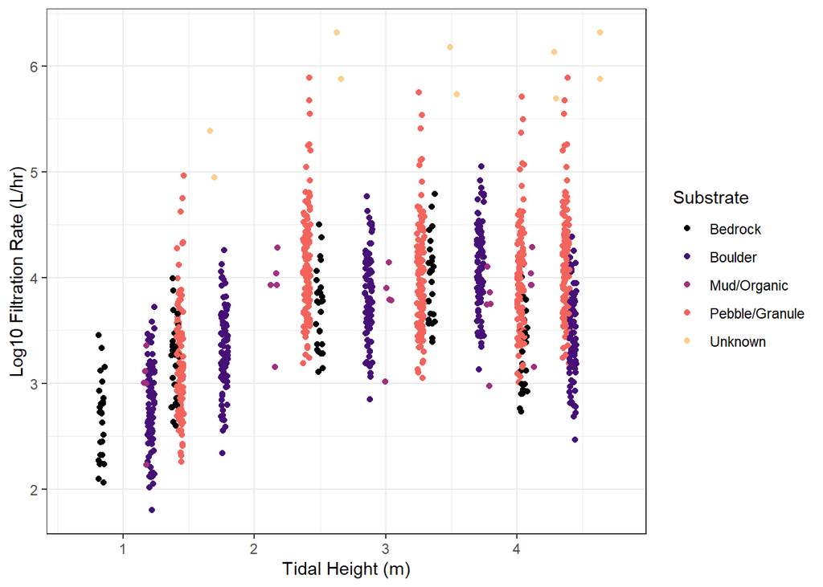

Estimated total log10 filtration rate for each each of the five mussel zones (defined by quadrat positions) for each polygon (n = 1140).

Total estimated cubic meters filtered per hour:

```
[1] 28290.25
```

#### Oyster filtration

Filtration rate of oysters in cubic meters per hour in Jakolof Bay assuming 975,745 oysters:

```
[1] 2614.461
```

Filtration rate of oysters in cubic meters per hour in Jakolof Bay assuming 1.5 million oysters:

```
[1] 4020
```